# Implementing automated section control sprayers for optimized pesticide application in orchards

Clemens Stephany, Christoph Weinmann, Lucas Hoffmann, Adrian Fülle, Jasper Hackling

6/1/2021

# 1 Abstract

In this project we are looking at a prototype of an automated section-control sprayer (ASCS) which is currently being tested at Competence Centre for Fruit Production Lake Constance (Kompetenzzentrum Obstbau Bodensee, KOB) in its first season. It is compared on a monetary background to a manual section-control sprayer (MSCS) which is the current standard technology for spraying pesticides in orchards. Most of the sprayers are blower sprayers.

The main calculation to look at is whether the reduction of running-costs of the ASCS through lower pesticide usage compared to the MSCS are higher than the increased initial investment for the more expensive sprayer.

Other factors taken into consideration are the influence the reduction of pesticide usage has on the biodiversity and water contamination. These factors influence the likelihood of the government setting a restriction on the maximum amount of allowed pesticide to be applied. In addition, these factors influence the customer behavior.

The output of the model generated in this project shows a continously higher net present value (NPV) for the ASCS after year one. In the first year the profit is heavily reduced due to the higher acqusition prize. The NPV is the discounted profit calculated based on the investment costs, running costs, damage to the fruits (apples) - calculated by combining applied pesticides (with a potential limit) and influences of the increased or decreased biodiversity - and the customer behavior.

# 2 Introduction

Reducing the use of pesticides in agricultural and horticultural production has been an important concern of policymakers, NGOs and also farmers for years. Not only is a reduction economically favorably on a farm level, but more and more negative impacts of the liberal use of agrochemicals on ecosystems have been reported in recent years. In orcharding, efforts have been made to make pesticide application more efficient in order to bring down the overall amount applied, while still securing fruit quality and stable yields. This led to the advent of blower sprayers capable of section control. This feature allows the operator to reduce or completely turn off the application of pesticides on a part of the total working width when it is appropriate. For instance, if a shorter tree comes up in a row of taller trees, the operator will manually turn off the topmost section of the blower sprayer to prevent pesticide being sprayed past the treetop into the environment.

While the manually-operated section control sprayer (MSCS) is generally able to reduce pesticide application rates while maintaining the effectiveness of the agent, the strain it puts on the operator is exhausting and requires properly trained and experienced personnel. This limits the overall work capacity of one unit. Furthermore, because of the complex handling, errors are likely to occur which diminishes the potential to reduce the ingress of agrochemicals into the environment.

Therefore, a novel technology is currently under development to automate the modulation of the section control feature of orchard sprayers. Light detection and ranging (LiDAR) sensors are mounted to the sprayer to allow a computer to assess the structure of the upcoming trees. This, in turn, enables the machine to appropriately adapt the individual sections according to the current requirements. Besides the immediate relief for the tractor driver, this technology also allows less experienced workers to operate section controlled sprayers. Therefore, an automatically-controlled section control sprayer (ASCS) has a higher work capacity than a MSCS, i.e. a larger area can be sprayed in a given amount of time. Apart from that, pesticide reduction can be improved due to the higher precision in modulating the application rate following the principle of “as little as possible, as much as necessary”.

All in all, the ASCS promises a more efficient application of pesticide and higher work capacity per sprayer, as well as less contamination of the environment while maintaining full effectiveness in terms of plant protection.

## 2.1 Short introduction to decision analysis

Decision analysis is a research approach aimed at developing rational recommendations to support real-word scenarios. When confronted with alternative options in a decision situation, decision makers often face complexity, limited information, and uncertainty about the factors influencing the system. Decision analysis deploys participatory methods to convene representatives of any stakeholder groups associated with the decision and its consequences (“Applying the mcSimulation Function in decisionSupport,” n.d.). The aim is to collect the current state of knowledge from experts and practitioners, while simultaneously creating awareness of the inevitable uncertainties associated with estimations (Denis et al., n.d.). By accepting and openly communicating uncertainties, the need to understand all aspects of a system typically prominent in science is eliminated. The introduction of Applied Information Economics by (Douglas W. 2014) advanced the field of decision analysis by establishing the use of probability distributions and value ranges instead of precisely measured values as inputs for probabilistic simulations. After these simulations have calculated the whole range of possible outcomes of the decision situation, knowledge gaps are identified where obtaining additional information would enhance the prediction precision. To start an iterative process of model improvement, measures are taken to improve the input data until the simulation output can confidently support the decision (Douglas W. 2014).

This approach has been applied in a number of different fields, e.g. business decision support (Ali E. and Ronald A., n.d.), public health intervention planning (Keith et al., n.d.), policy process support (Michael, n.d.), and natural resource management (Byron K. and Fred A., n.d.).

# 3 Intervention

One of the aforementioned orchard farmers is in the market for a new pesticide sprayer because the one currently in use is approaching the end of its operational life (technologically outdated, repair costs, tax reasons). As it is the state of the art, a section control sprayer is considered to be purchased. The farmer faces the choice between i) a typical manually operated section control sprayer (MSCS) or ii) an automated section control sprayer (ASCS) that relies on LiDAR technology. As non-section control sprayer are outdated, such models are not taken into consideration here.

The initial investment costs for the ASCS option are higher up front compared to the MSCS option which involved less technical equipment, but several benefits can be expected from the automated sprayer, which may have direct or indirect economic effects on the operating income of the orchard. In essence, the intervention situation is whether or not the orchard farmer should invest the extra expenses on the technically more sophisticated sprayer option (ASCS) instead of opting for the standard MSCS.

# 4 Decision maker

Constituting the core of every decision analysis is the decision maker. This may be a single person, but an institution or any other body can also be the decision maker in a particular situation (“Applying the mcSimulation Function in decisionSupport,” n.d.). In our case, we identified German orchard farmers for this role, in particular those located in southern Germany where fruit production in orchards is widely spread and quite intensive. We define the orchard farmer as the farm manager who is in charge of investment decision into new equipment. As he or she is typically familiar with the situation on the orchard farm and aware of any small details that play into an investment decision from an operational point of view, the farm manager plays a crucial role in our decision model and is among the most important stakeholders of the decision.

# 5 Stakeholders

Several different institutions, groups of people, and other bodies are involved in the decision. They may either take part directly in the decision by communication and correspondence among the groups, or be indirectly affected by the decision and the consequences that ensue. Among them are, most importantly, the orchard farmer taking the investment decision and other farmers in a similar situation. Apart from that we identified the manufactures of orchards sprayers, local water suppliers, the Land and federal government, non-government organizations (NGOs), consumers and customers, food retailers, agrochemical companies, beekeepers and the local biodiversity as stakeholders.

# 6 Data acquistion

## 6.1 Research

For our project work we researched important values and facts, which we used to develop the questions for the calibration training, our questionnaire and also for our model.

We used different tools to find out the values and facts we needed. We used different platforms like google scholar to find paper which related to our topic. We also used different official websites from the german authorities like the Federal Office of Statistics for statistical data or values like how much area is used for orcharding, the Federal Environmental Agency for data about plant protection and the Federal Ministry of Finance.

Regarding prices and technology information about sprayers, we used websites from agricultural machinery producers but also agricultural information websites.

## 6.2 Expert knowledge

For the decision-relevant questions, we consulted various stakeholders as experts for our model. We consulted several scientists from different apple growing regions in germany, leaders and technical assistants from the area of plant health, plant protection and production technology of the Competence Center for Fruit Production Lake Constance, as well as farmer from the lake constance region.

## 6.3 Calibration training

For a decision analysis it is important to know how valuable the given estimates are, because it should be based on comprehensive and reliable knowledge. Therefore, calibration training is applied.

Calibration is a process to find out and document how strong the deviation of an estimation form the reality is and how certain the aspiring expert was. This documentation is used to point flaws in estimating out and to level the playing field for further discussions. Due to calibration training the affective answering behavior is reduced and it helps to improve the given estimates. It also trains you to know your uncertainties and to give good estimates (Cory and Eike n.d.).

In this case experts are used as a substitution of measuring devices. The answers are normally linked to various cognitive biases and normally lead to an overconfidence of the experts about their estimates (Cory and Eike n.d.).

To reduce this, a series of basic questions is used. In the first part of the calibration training the soon-to-be experts need to answer questions where the correct answer must be within a certain range. In the second part they need to answer yes or no questions and they need to estimate their confidence about the given answers beeing correct. After answering the basic questions, they get the feedback about the given answers and their confidence intervals. This leads to a reduction of overconfidence (Cory and Eike n.d.).

After completing our calibration training, they were asked about estimates to all inputs for our model with a 90% confidence interval.

## 6.4 Questionnaire

In order to get reliable data we decided to do a short questionnaire and hand it out to experts from the “Kompetenzzentrum Obstbau Bodensee”.

Before the Experts were asked the important questions, we needed values to, they had to answer general questions, so called calibrations questions. Find an explanation for the calibration training above. These questions were asked to make the experts aware of possible estimation mistakes and bring down their possible overconfidence about their answers.

In our Questionnaire we asked the experts to answer six questions where we needed upper and lower boundaries. We asked these questions to get reliable values from experts, because there was no open source information for these specific questions.

The first three questions were related to the cost of a new sprayer, how long this one can be used to apply plant protection agents in orcharding and how much area can be sprayed with one sprayer. To find prices for new sprayers is very difficult because the agricultural machinery producers provide them only for interested customers, since it is not fully on the market yet. That’s way this question was asked. For the durability of sprayers there is no available information, because it depends on how much it will be used and how. The experts should have a good knowledge about the durability of a sprayer in orcharding. The third question was asked because in orcharding you should be able to spray all trees in a specified amount of time if there is an important treatment which needs to be done quickly. One section controlled sprayer can not be used for 100 hectare or more like in normal farming.

The next three questions were related to the cost of plant protection products per hectare, the percentages of plant protection which gets lost through different influences and about the possibility to reduce these losses with the new automated sprayers. Plant protection is a costly factor in orcharding and important for calculating our model. Therefore, we asked the experts for their estimates. The question about the lost percentage due to drift or space between the trees was a difficult question, because no values could be found on the internet. The last question was asked to find out what the experts think about the possibility that the new technology could reduce the losses.

## 6.5 Input tabel

We split the input table in three sections:

- variables with a `const` distribution
- variables with a `posnorm` distribution
- variables with a `tnorm_0_1` distribution

Included in the first section are mostly our relative variables, like the relative biodiversity or water contamination (`rel_biodiversity`, `rel_water_contamination`). These start at a value of `1` in the first year, but increase or decrease over time. The only odd one in this section might be `n_years`, which is set to 10, because our model is at the moment intended to run for this long. This is still adjustable depending on possible other decisions with varying circumstances.

| variable | lower | median | upper | distribution | label | units |
| --- | --- | --- | --- | --- | --- | --- |
| customer_on_fruitsales | 1 | NA | 1 | const | customer buying behavior | status quo |
| government_pesticide_quantity | 1 | NA | 1 | const | governmental pesticide qunatity | guideline |
| n_years | 10 | NA | 10 | const | lifespan of the machine | years |
| potential_plant_damage | 1 | NA | 1 | const | potential plant damage | status quo |
| rel_biodiversity | 1 | NA | 1 | const | biodiversity | constant |
| rel_water_contamination | 1 | NA | 1 | const | water contamination | constant |

The second section describes our frequentative, so noniterative, variables. Included here are e.g. the initial costs of the sprayers (`initial_man_cost`, `initial_upg_cost`), but also percentage values like the achievable pesticide reduction, through using the automated sprayer (`pesticide_reduction_auto`). Odd variables might seemingly be the `discount_rate` and the `var_CV`, but both of them belong to the positive-normal distributed section.

| variable | lower | median | upper | distribution | label | units |
| --- | --- | --- | --- | --- | --- | --- |
| area_per_machine | 1.5e+01 | NA | 2.0e+01 | posnorm | effective area of one machine | ha |
| discount_rate | 2.0e+00 | NA | 5.0e+00 | posnorm | discount rate | % |
| farmers_pesticide_quantity_miscalculation | 9.0e-01 | NA | 1.1e+00 | posnorm | farmers miscalculation of pesticide quantity | std |
| government_reaction_time | 2.0e+00 | NA | 6.0e+00 | posnorm | time delay of government decision | years |
| initial_man_cost | 1.8e+04 | NA | 3.0e+04 | posnorm | initial costs normal sprayer | euro |
| initial_upg_cost | 5.0e+03 | NA | 7.0e+03 | posnorm | initial upgrade cost | euro |
| market_price | 5.0e+02 | NA | 8.0e+02 | posnorm | market price euro/t | Euro/t |
| pesticide_cost | 1.4e+03 | NA | 2.2e+03 | posnorm | pesticide costs | euro/ha |
| pesticide_reduction_auto | 5.0e-02 | NA | 1.5e-01 | posnorm | reduction of pesticide quantity | % |
| potential_plant_damage_CV | 5.0e+00 | NA | 1.5e+01 | posnorm | potential plant damage co-variation | % |
| var_CV | 5.0e+00 | NA | 2.5e+01 | posnorm | standard co-variation | % |
| yield | 2.0e+01 | NA | 6.0e+01 | posnorm | yield t/ha | t/ha |

Mostly influence factors are present in our last section. These describe the influence that e.g. the pesticides have on the biodiversity (`pesticide_on_biodiversity_factor`). The `government_intervention_chance` is sorted in here as well, as it is also a procentual value in the range from 0 to 1.

| variable | lower | median | upper | distribution | label | units |
| --- | --- | --- | --- | --- | --- | --- |
| biodiversity_on_customer | 0.050 | NA | 0.10 | tnorm_0_1 | biodiversity effect on government | % |
| biodiversity_on_gov_concern | 0.050 | NA | 0.15 | tnorm_0_1 | biodiversity effect on government | % |
| government_intervention_chance | 0.050 | NA | 0.15 | tnorm_0_1 | chance of government intervention | % |
| pesticide_on_biodiversity_factor | 0.001 | NA | 0.05 | tnorm_0_1 | pesticide effect on biodiversity | % |
| pesticide_on_water_contamination_factor | 0.050 | NA | 0.15 | tnorm_0_1 | pesticide effect on water contamination | % |
| water_contamination_on_biodiversity_factor | 0.001 | NA | 0.05 | tnorm_0_1 | water contamination effect on pesticide | % |
| water_contamination_on_customer | 0.010 | NA | 0.05 | tnorm_0_1 | water contamination effect on customer | % |
| water_contamination_on_gov_concern | 0.100 | NA | 0.20 | tnorm_0_1 | water contamination effect on government | % |

# 7 Model

## 7.1 Flow chart

The following graph is meant to give a better understanding of our model. We included two different sprayers, the automated and the manual sprayer seen on the far left of the model. Those mainly effect the amount of needed pesticides and plant protection agents but also the initial cost. Pesticides are the main factor in our model. They effect water contamination, biodiversity, plant damage and the cost through the amount applied.

We chose the duration of our model to be 10 years since most farmers replace their sprayers around this time. The model had to be partly iterative, since most variables have an effect on variables in the following years.

One Example for this is the amount we spray and the plant damage. If the farmer sprayed enough then there won’t be any damage, but if he or she estimated the amount incorrectly and sprayed less then needed, then the plant damage in the following year will be effected.  
Something similar can be said about the customers. If we spray a lot then the water contamination increases and the biodiversity on the field decreases, this change is being picked up by the customers through the news, magazines or first hand if they are residents nearby.

Existing plant damage and fewer customers will reduce the harvest and thus lessen the fruit sales. The sales and minus the overall costs will create the farmers profit, which is the output variable we want to analyze.

Lastly we also included an event, representing the government intervening in the amount we are allowed to spray. This has an impact especially in years the farmer has to spray a lot. Here the impact on the manual sprayer will be bigger, as the automated sprayer reduces the overall amount of needed pesticides. The chance of the government intervening is initially set low, but is influenced by the water contamination and the biodiversity. We also included a delay between the government decision and the implementation of it. This delay can vary between two and six years, because various governmental institutions or decisions take less time than others.

```r
model_flow_chart <- grViz("

digraph {

  # Add general information which counts for everything!!!

  # ---------
  # Change flow chart orientation (top down: 'TD'; left to right: 'LR'
  rankdir = 'LR'

  # Add graph statements
  graph [#label = 'Initial Model',
         labelloc = t,
         fontsize = 45,
         ranksep=2,
         nodesep=1]

  # Add node statements
  node [fontname = Arial,
        fontcolor = black,
        color = darkslategray,
        penwidth = 1]

  # Add edge statements
  edge [fontsize=30,
        penwidth=2,
        fontname=Arial]
  # ---------

  # ---------
  # create 'ranks' (basically nodes) for arranging nodes later on
  rank1 [style=invis]
  rank2 [style=invis]
  rank3 [style=invis]
  rank4 [style=invis]
  rank5 [style=invis]

  # make invisible (white) links between them
  rank1->rank2->rank3->rank4->rank5 [color=white]
  # ---------

  # ---------
  # Add specific statements for node group {Intervention & Alternatives}
  node [shape = box,
        fontsize = 30,
        fixedsize = true,
        width = 3.6,
        height = 1.5]

    Ascs [label = 'Automated section \n control sprayer'];
    Al1 [label = 'Manual section \n control sprayer'];
  # ---------



  # Add specific statements for node group {Pesticides & Cost}
  # ---------
  node [shape = box,
        fontsize = 28,
        fixedsize = true,
        width = 2.8,
        height = 0.9]

  Pe [label = 'Pesticides'];
  Co [label = 'Cost']

  Cu [label = 'Customers'];
  Di [label = 'Plant damage'];
  Bio [label = 'Biodiversity'];
  WC [label = 'Water \n contamination'];

  FS [label = 'Fruit sales'];
  GC [label = 'Government \n concerns'];

  FP [label = 'Farmers profit']

  # ---------


  # Add edge statements for negative connection (arrows) and add the connections
  # ---------
  edge [label = '-    ',
        fontcolor = 'red',
        color = 'red']
  {Ascs Al1} -> Pe #[headport = w, tailport = e]
  GC -> Pe
  Pe->Bio #[headport = w]
  Pe-> Di
  Bio->{Di GC}
  WC->{Bio Cu}
  Di->FS
  Co->FP
  # ---------

  # Add edge statements for positive connection (arrows) and add the connections
  # ---------
  edge [label = '+',
        fontcolor = 'forestgreen',
        color = 'forestgreen']

  {Ascs Al1}->Co #[headport = w, tailport = s]
  Pe-> WC  #[headport = w, tailport = n]
  Pe-> Co
  FS->FP
  WC->GC
  Bio-> Cu
#  Di -> Pe
  Cu->FS
  # ---------

  # ---------
  # sorting the nodes per rank

  {
    Ascs -> Al1 -> rank1 [style=invis];
    rank=same;
    rankdir=TD;
  }

  {
    Co -> Pe -> GC -> rank2 [style=invis];
    rank=same;
    rankdir=TD;
  }

  {
    Di -> Bio -> WC -> rank3 [style=invis];
    rank=same;
    rankdir=TD;
  }

  {
    Cu -> FS -> rank4 [style=invis];
    rank=same;
    rankdir=TD;
  }

#   {
#     rank5 -> FS [style=invis];
#     rank=same;
#     rankdir=DT;
#   }
#
  # ---------

}")
```

[interactive chart not shown]

## 7.2 Code

### Walkthrough

In the following chapters we show and explain the code of our model chunk by chunk. To see the code in its entirety please consult the tab Full Code next to this one.

#### Input data

The first step in creating our model is to load in our input variables from the excel file.  
We optionally tidy our file up with `drop_na`, `filter`, `order` and write the clean file to a new directory. Now we import the final excel file.  
In the Script we often use the `_man` or `_aut` abbreviation as an suffix to indicate which sprayer (ASCS or MSCS) variables we are modifying.

[output not shown]

After we loaded in all our predefined variables we need to define the iterative variables. For this we start writing our function `ascs_decision_model`.  
We created an `auxiliary_table` with `n_years` amount of rows and all the relevant variables in the columns, to make the calculations of the variables faster.  
At this point we defined the values for each year as `0`.

```
ascs_decision_model <- function(x, varnames){

  auxiliary_table <- data.frame(year = c(1:n_years),
                                pest_quant_man = rep(0.,n_years),
                                pest_quant_aut = rep(0.,n_years),
                                rel_water_cont_man = rep(0.,n_years),
                                rel_water_cont_aut = rep(0.,n_years),
                                rel_bio_man = rep(0.,n_years),
                                rel_bio_aut = rep(0.,n_years),
                                plant_dmg_pot_man = rep(0.,n_years),
                                plant_dmg_pot_aut = rep(0.,n_years),
                                actual_plant_dmg_man = rep(0.,n_years),
                                actual_plant_dmg_aut = rep(0.,n_years),
                                gov_inter_chance_man = rep(0.,n_years),
                                gov_inter_chance_aut = rep(0.,n_years),
                                gov_inter_happened_man = rep(0,n_years),
                                gov_inter_happened_aut = rep(0,n_years),
                                gov_reaction = rep(0,n_years)
                                )
```

#### For-loop

##### First year

To iterate through each year we set the `for`-loop to be `n_years` long. Furthermore we kept in mind that `n_years` can vary and kept our model dynamic and easily adaptable for other cases.

The next step in the `for`-loop is to overwrite all the iterative variables for the first year (`if (y == 1)`. Here we first change the government reaction to a number randomly derived from between the `government_reaction_time` boundaries from the input table. This delay is used later on and represents the time between the government decision and its implementation.

The `chance` that the government intervenes is covered by (pre-)assumptions for the first year, it is directly taken from the input table. In later years it will be effected by the biodiversity and water contamination.

We also make sure that the government intervention happens only inside the `n_years` boundaries, because it wouldn’t have any effect on our model.

```
  for (y in 1:n_years) {

    if (y == 1) {
    lower <- input_table[input_table$variable ==
                           "government_reaction_time", "lower"]
    upper <- input_table[input_table$variable ==
                           "government_reaction_time", "upper"]
    auxiliary_table$gov_reaction <- round(runif(n_years,lower,upper))

    auxiliary_table$gov_inter_chance_man[y] <- government_intervention_chance
    auxiliary_table$gov_inter_chance_aut[y] <-
      auxiliary_table$gov_inter_chance_man[y]

    if ((y + auxiliary_table$gov_reaction[y]) <= n_years) {
      auxiliary_table$gov_inter_happened_man[y +
        auxiliary_table$gov_reaction[y]] <- chance_event(
        auxiliary_table$gov_inter_chance_man[y], 1, 0)
      auxiliary_table$gov_inter_happened_aut[y +
        auxiliary_table$gov_reaction[y]] <- chance_event(
        auxiliary_table$gov_inter_chance_aut[y], 1, 0)
    }
```

In the following part we use the `vv()` function to get values for the influence factors. Those include the influence from pesticides on water contamination and biodiversity but also from water contamination on biodiversity. Further we import the factor that describes how much reduction can be achieved by using the automated sprayer (`pesticide_reduction_auto`) from the input table. This value gets subtracted from 1 to get a reduction by multiplying with this factor.

```
    pest_cont_fac <- vv(pesticide_on_water_contamination_factor, var_CV, 1)
    pest_bio_fac <- vv(pesticide_on_biodiversity_factor, var_CV, 1)
    cont_bio_fac <- vv(water_contamination_on_biodiversity_factor, var_CV, 1)

    pest_red_fac <- 1 - pesticide_reduction_auto
```

To get to the actual plant damage we initially define a potential plant damage for every year. This potential damage will be effected by the amount of pesticides sprayed and the biodiversity changes in the following years.

Now we let the pesticide quantity correlate with the potential plant damage.  
The idea here is that the farmer tries to spray enough but not to much. This estimation is prone to errors, so we chose to multiply the potential plant damage with a randomly drawn number from the 90% confidence interval of the borders defined in the `farmers_pesticide_quantity_miscalculation` variable.  
The amount of pesticide usage for the automated sprayer is further multiplied by the pesticide reduction factor (`pest_red_fac`). This represents the further reduction of pesticide usage through using the ASCS instead of the MSCS.

```
    auxiliary_table$plant_dmg_pot_man <-
      vv(potential_plant_damage, potential_plant_damage_CV, n_years)
    auxiliary_table$plant_dmg_pot_aut <- auxiliary_table$plant_dmg_pot_man

    lower <- input_table[input_table$variable ==
                           "farmers_pesticide_quantity_miscalculation", "lower"]
    upper <- input_table[input_table$variable ==
                           "farmers_pesticide_quantity_miscalculation", "upper"]
    auxiliary_table$pest_quant_man <-
      auxiliary_table$plant_dmg_pot_man *
      rposnorm90ci(n_years, lower = lower, upper = upper)
    auxiliary_table$pest_quant_aut <-
      auxiliary_table$pest_quant_man *
      pest_red_fac
```

We decided that the biodiversity and water contamination will be relative and set it for the first year to 1. They will increase or decrease in the following years, depending on the pesticide usage.  
The amount that was sprayed is subtracted from potential plant damage to get to the actual plant damage.  
We made an optional check to make sure that the actual plant damage is not below zero.

```
    auxiliary_table$rel_water_cont_man[y] <- 1
    auxiliary_table$rel_water_cont_aut[y] <- 1
    auxiliary_table$rel_bio_man[y] <- 1
    auxiliary_table$rel_bio_aut[y] <- 1

    actual_plant_dmg_man <- auxiliary_table$plant_dmg_pot_man[y] -
      auxiliary_table$pest_quant_man[y]
    auxiliary_table$actual_plant_dmg_man[y] <- ifelse(actual_plant_dmg_man < 0,
      0, actual_plant_dmg_man)

    actual_plant_dmg_aut <- auxiliary_table$plant_dmg_pot_aut[y] -
      auxiliary_table$pest_quant_aut[y] / pest_red_fac
    auxiliary_table$actual_plant_dmg_aut[y] <- ifelse(actual_plant_dmg_aut < 0,
      0, actual_plant_dmg_aut)
```

With this we are finished with everything regarding the first year. If you want to check the calculations for the second and following years, you need to go back to the beginning of the For-loop chapter and select the corresponding tab.

##### Following years

For the following years (year 2 - `n_years`) a lot of variables are varying.

The first change is in the chance for the government intervention. This is depending on the variation in biodiversity and water contamination.  
We also check for the chance being between 1 and 0.

```
    }else {
    auxiliary_table$gov_inter_chance_man[y] <-
      auxiliary_table$gov_inter_chance_man[y-1] +
      ( ((1 - auxiliary_table$rel_bio_man[y-1]) * biodiversity_on_gov_concern) +
      ((auxiliary_table$rel_water_cont_man[y-1] - 1) *
         water_contamination_on_gov_concern))

    auxiliary_table$gov_inter_chance_aut[y] <-
      auxiliary_table$gov_inter_chance_aut[y-1] +
      ( ((1 - auxiliary_table$rel_bio_aut[y-1]) * biodiversity_on_gov_concern) +
      ((auxiliary_table$rel_water_cont_aut[y-1] - 1) *
         water_contamination_on_gov_concern))

    auxiliary_table$gov_inter_chance_man[y] <-
      ifelse(auxiliary_table$gov_inter_chance_man[y] <= 0,
             0,
             ifelse(auxiliary_table$gov_inter_chance_man[y] >= 1,
                    1,
                    auxiliary_table$gov_inter_chance_man[y]))

    auxiliary_table$gov_inter_chance_aut[y] <-
      ifelse(auxiliary_table$gov_inter_chance_aut[y] <= 0,
             0,
             ifelse(auxiliary_table$gov_inter_chance_aut[y] >= 1,
                    1,
                    auxiliary_table$gov_inter_chance_aut[y]))
```

Now for the `chance_event` function itself.  
The event can only take place if the intervention delay added to the current year lies inside the `n_years` range and there was no intervention in the last year or in the relevant year already.  
If the event takes place, then the amount of pesticides legally allowed to be sprayed will be changed to a fixed number for the relevant years and following. This will have an especially big impact on the manual sprayer, since the amount sprayed by the automated sprayer is always lower.

```
    if(auxiliary_table$gov_inter_happened_man[y-1] == 0){
      if(y + auxiliary_table$gov_reaction[y] <= n_years){
        if(auxiliary_table$gov_inter_happened_man[
          y + auxiliary_table$gov_reaction[y]] == 0){
          auxiliary_table$gov_inter_happened_man[
            y + auxiliary_table$gov_reaction[y]] <-
            chance_event(auxiliary_table$gov_inter_chance_man[y], 1, 0)
        }
      }
    }else{
      auxiliary_table$gov_inter_happened_man[y] <- 1
    }

    if(auxiliary_table$gov_inter_happened_aut[y-1] == 0){
      if(y + auxiliary_table$gov_reaction[y] <= n_years){
        if(auxiliary_table$gov_inter_happened_aut[
          y + auxiliary_table$gov_reaction[y]] == 0){
          auxiliary_table$gov_inter_happened_aut[
            y + auxiliary_table$gov_reaction[y]] <-
            chance_event(auxiliary_table$gov_inter_chance_aut[y], 1, 0)
        }
      }
    }else{
      auxiliary_table$gov_inter_happened_aut[y] <- 1
    }
```

To get the values of biodiversity and water contamination of the current year, we multiply the pesticide quantity from the last year with the respective influence factor and add it to the biodiversity and water contamination of last year. The current biodiversity is additionally influenced through the water contamination of the last year.

```
    auxiliary_table$rel_water_cont_man[y] <-
      auxiliary_table$rel_water_cont_man[y-1] +
      ((auxiliary_table$pest_quant_man[y-1] - 1) * pest_cont_fac)
    auxiliary_table$rel_water_cont_aut[y] <-
      auxiliary_table$rel_water_cont_aut[y-1] +
      ((auxiliary_table$pest_quant_aut[y-1] - 1) * pest_cont_fac)

    auxiliary_table$rel_bio_man[y] <- auxiliary_table$rel_bio_man[y-1] +
      ((1 - auxiliary_table$pest_quant_man[y-1]) * pest_bio_fac) +
      ((1 - auxiliary_table$rel_water_cont_man[y-1]) * cont_bio_fac)
    auxiliary_table$rel_bio_aut[y] <- auxiliary_table$rel_bio_aut[y-1] +
      ((1 - auxiliary_table$pest_quant_aut[y-1]) * pest_bio_fac) +
      ((1 - auxiliary_table$rel_water_cont_aut[y-1]) * cont_bio_fac)
```

The present potential plant damage and pesticide quantity get reduced by the newly calculated biodiversity. The idea here is that the pests get reduced through the higher biodiversity.

```
    auxiliary_table$plant_dmg_pot_man[y] <-
      auxiliary_table$plant_dmg_pot_man[y] +
      auxiliary_table$plant_dmg_pot_man[y] *(1 -  auxiliary_table$rel_bio_man[y])
    auxiliary_table$plant_dmg_pot_aut[y] <-
      auxiliary_table$plant_dmg_pot_aut[y] +
      auxiliary_table$plant_dmg_pot_aut[y] *(1 -  auxiliary_table$rel_bio_aut[y])

    auxiliary_table$pest_quant_man[y] <- auxiliary_table$pest_quant_man[y] +
      auxiliary_table$pest_quant_man[y] * (1 - auxiliary_table$rel_bio_man[y])
    auxiliary_table$pest_quant_aut[y] <- (auxiliary_table$pest_quant_aut[y] +
      auxiliary_table$pest_quant_aut[y] * (1 - auxiliary_table$rel_bio_aut[y]))
```

Since everything in the `if`-loop part is calculated for the first year only, the actual plant damage and the effect of the intervention must be calculated for the following years again.

```
    auxiliary_table$pest_quant_man[y] <-
  ifelse(auxiliary_table$gov_inter_happened_man[y] == 0,
         auxiliary_table$pest_quant_man[y],
         ifelse(auxiliary_table$pest_quant_man[y] >
                  government_pesticide_quantity,
                government_pesticide_quantity,
                auxiliary_table$pest_quant_man[y]))

    auxiliary_table$pest_quant_aut[y] <-
      ifelse(auxiliary_table$gov_inter_happened_aut[y] == 0,
             auxiliary_table$pest_quant_aut[y],
             ifelse(auxiliary_table$pest_quant_aut[y] >
                      government_pesticide_quantity,
                    government_pesticide_quantity,
                    auxiliary_table$pest_quant_aut[y]))

    actual_plant_dmg_man <-
      auxiliary_table$plant_dmg_pot_man[y] -
      auxiliary_table$pest_quant_man[y]
    auxiliary_table$actual_plant_dmg_man[y] <- ifelse(actual_plant_dmg_man < 0,
                                                      0,
                                                      actual_plant_dmg_man)

    actual_plant_dmg_aut <-
      auxiliary_table$plant_dmg_pot_aut[y] -
      auxiliary_table$pest_quant_aut[y] /
      pest_red_fac
    auxiliary_table$actual_plant_dmg_aut[y] <- ifelse(actual_plant_dmg_aut < 0,
                                                      0,
                                                      actual_plant_dmg_aut)
  }
```

#### Output

Many variables are not iterative but still vary:

- `yield` depending on the year and plant damage
- `market prices` depending on the year
- `fruit sales` depending on the yield and the market price
- `pesticide costs per hectare` depending on the year
- `pesticide costs per hectare and sprayer` depending additionally on the amount sprayed
- `machine costs` depending on the brand, year, and if its automated or manual
- `customers` depending on biodiversity and water contamination
- `profit` depending on fruit sales, pesticide costs, hectare, customers and machine costs

```
    yield_t_ha <- vv(yield, var_CV, n_years)
    yield_t_ha_man <- yield_t_ha * (1 - auxiliary_table$actual_plant_dmg_man)
    yield_t_ha_aut <- yield_t_ha * (1 - auxiliary_table$actual_plant_dmg_aut)

    market_price_e_t <- vv(market_price, var_CV, n_years)

    fruit_sales_e_ha_man <- yield_t_ha_man * market_price_e_t
    fruit_sales_e_ha_aut <- yield_t_ha_aut * market_price_e_t

    pest_cost_ha_const <- vv( pesticide_cost, var_CV, n_years )
    pest_cost_ha_man <- pest_cost_ha_const * auxiliary_table$pest_quant_man
    pest_cost_ha_aut <- pest_cost_ha_const * auxiliary_table$pest_quant_aut

    machine_cost_man <- c( initial_man_cost, rep( 0, (n_years-1) ) )
    machine_cost_aut <- machine_cost_man + c( initial_upg_cost,
                                              rep( 0, (n_years-1) ) )

    customers_man <- rep(customer_on_fruitsales, n_years) +
      (auxiliary_table$rel_bio_man - 1) * biodiversity_on_customer +
      (1 - auxiliary_table$rel_water_cont_man) * water_contamination_on_customer
    customers_aut <- rep(customer_on_fruitsales, n_years) +
      (auxiliary_table$rel_bio_aut - 1) * biodiversity_on_customer +
      (1 - auxiliary_table$rel_water_cont_aut) * water_contamination_on_customer

    farmers_profit_man = (fruit_sales_e_ha_man * customers_man -
                            pest_cost_ha_man) * area_per_machine - machine_cost_man
    farmers_profit_aut = (fruit_sales_e_ha_aut * customers_aut -
                            pest_cost_ha_aut) * area_per_machine - machine_cost_aut
```

The profits get discounted to generate the respective net present value. We chose a discount rate between 2 and 5 %, since our farmers are likely to invest.  
In the end we return the calculated NPVs, the difference between the NPVs and the cashflow to further plot and analyze them.

```
    NPV_aut = discount(farmers_profit_aut, discount_rate, calculate_NPV = TRUE)
    NPV_man = discount(farmers_profit_man, discount_rate, calculate_NPV = TRUE)

    return(list(Interv_NPV = NPV_aut,
                NO_Interv_NPV = NPV_man,
                NPV_decision_do = NPV_aut - NPV_man,
                Cashflow_decision_do = farmers_profit_aut - farmers_profit_man))
}
```

### Full model code

As a reference we added the whole model code with short comments to make it more readable as a whole.

```r
# Importing and adjusting input table
input_table <- read.csv("data/input_data_03.csv", sep = ";", dec = ",",
                        stringsAsFactors = FALSE)
input_table <- drop_na(input_table, c("lower","upper"))
input_table <- filter(input_table, !variable == "initial_aut_cost",
                      !variable == "pesticide_quantity")
input_table <- input_table[ order(input_table$distribution,
                                  input_table$variable), ]
write.csv(input_table, "data/final/inputs.csv", row.names = FALSE)
input_table <- read.csv("data/final/inputs.csv", stringsAsFactors = FALSE)


ascs_decision_model <- function(x, varnames){

  # table for iterative impacted variables
  auxiliary_table <- data.frame(year = c(1:n_years),
                                pest_quant_man = rep(0.,n_years),
                                pest_quant_aut = rep(0.,n_years),
                                rel_water_cont_man = rep(0.,n_years),
                                rel_water_cont_aut = rep(0.,n_years),
                                rel_bio_man = rep(0.,n_years),
                                rel_bio_aut = rep(0.,n_years),
                                plant_dmg_pot_man = rep(0.,n_years),
                                plant_dmg_pot_aut = rep(0.,n_years),
                                actual_plant_dmg_man = rep(0.,n_years),
                                actual_plant_dmg_aut = rep(0.,n_years),
                                gov_inter_chance_man = rep(0.,n_years),
                                gov_inter_chance_aut = rep(0.,n_years),
                                gov_inter_happened_man = rep(0,n_years),
                                gov_inter_happened_aut = rep(0,n_years),
                                gov_reaction = rep(0,n_years)
                                )


  for (y in 1:n_years) {

    if (y == 1) { # first year
      # fix for one run
      ## generating a vector for the government reaction delay
      lower <- input_table[input_table$variable ==
                             "government_reaction_time", "lower"]
      upper <- input_table[input_table$variable ==
                             "government_reaction_time", "upper"]
      auxiliary_table$gov_reaction <- round(runif(n_years,lower,upper))

      # general chance that government intervenes
      # in year 1 this is covered by (pre-)assumptions
      ## will be affected by biodiversity and water contamination later on
      auxiliary_table$gov_inter_chance_man[y] <-
        government_intervention_chance
      auxiliary_table$gov_inter_chance_aut[y] <-
        auxiliary_table$gov_inter_chance_man[y]
      # chance event of government intervention takes only place if the reaction
      # delay is inside our n_years boundaries
      if ((y + auxiliary_table$gov_reaction[y]) <= n_years) {
        auxiliary_table$gov_inter_happened_man[
          y + auxiliary_table$gov_reaction[y]] <- chance_event(
            auxiliary_table$gov_inter_chance_man[y], 1, 0)

        auxiliary_table$gov_inter_happened_aut[
          y + auxiliary_table$gov_reaction[y]] <- chance_event(
            auxiliary_table$gov_inter_chance_aut[y], 1, 0)
      }
      # influence factor from pesticides on water contamination ## fix per run
      pest_cont_fac <- vv(pesticide_on_water_contamination_factor, var_CV, 1)
      # influence factor from pesticides on biodiversity ## fix per run
      pest_bio_fac <- vv(pesticide_on_biodiversity_factor, var_CV, 1)
      # influence factor from water contamination on biodiversity ## fix per run
      cont_bio_fac <- vv(water_contamination_on_biodiversity_factor, var_CV, 1)
      # pesticide reduction factor when using the automated sprayer
      ## 1- because it would be negativ in the pls analysis otherwise
      pest_red_fac <- 1 - pesticide_reduction_auto

      # potential plant damage vector for n_years
      # its the same for both decisions
      ## will be affected by biodiversity later on
      auxiliary_table$plant_dmg_pot_man <-vv(potential_plant_damage,
                                             potential_plant_damage_CV, n_years)
      auxiliary_table$plant_dmg_pot_aut <-auxiliary_table$plant_dmg_pot_man

      # manual correlation between pesticide quantity and potential plant damage
      ## the farmer tries to assess how much plant damage there will be and sets
      ## the applied pest quantity accordingly
      lower <- input_table[input_table$variable ==
                             "farmers_pesticide_quantity_miscalculation","lower"]
      upper <- input_table[input_table$variable ==
                             "farmers_pesticide_quantity_miscalculation","upper"]
      auxiliary_table$pest_quant_man <- auxiliary_table$plant_dmg_pot_man *
        rposnorm90ci(n_years, lower = lower, upper = upper)
      auxiliary_table$pest_quant_aut <- auxiliary_table$pest_quant_man *
        pest_red_fac

      # biodiversity and water contamination are 1 in the first year ("status quo")
      auxiliary_table$rel_water_cont_man[y] <- 1
      auxiliary_table$rel_water_cont_aut[y] <- 1

      auxiliary_table$rel_bio_man[y] <- 1
      auxiliary_table$rel_bio_aut[y] <- 1

      # actual plant damage
      ## actual plant damage = potential plant damage - quantity sprayed
      ## the automated needs less spraying to counter the same amount
      ## of potential plant damage (/ pest_red_fac)
      actual_plant_dmg_man <- auxiliary_table$plant_dmg_pot_man[y] -
        auxiliary_table$pest_quant_man[y]
      auxiliary_table$actual_plant_dmg_man[y] <-ifelse(actual_plant_dmg_man < 0,
                                                       0,
                                                       actual_plant_dmg_man)

      actual_plant_dmg_aut <- auxiliary_table$plant_dmg_pot_aut[y] -
        auxiliary_table$pest_quant_aut[y] / pest_red_fac
      auxiliary_table$actual_plant_dmg_aut[y] <-ifelse(actual_plant_dmg_aut < 0,
                                                       0,
                                                       actual_plant_dmg_aut)
```

```r
    }else  {  # ongoing years (year 2 - n_years)
      ## the values change per year so the influence changes as well
      # government intervention chance
      ## general chance affected by biodiversity and water contamination
      auxiliary_table$gov_inter_chance_man[y] <-
        auxiliary_table$gov_inter_chance_man[y-1] +
        ( ((1 - auxiliary_table$rel_bio_man[y-1]) *
             biodiversity_on_gov_concern) +
            ((auxiliary_table$rel_water_cont_man[y-1] - 1) *
               water_contamination_on_gov_concern))

      auxiliary_table$gov_inter_chance_aut[y] <-
        auxiliary_table$gov_inter_chance_aut[y-1] +
        ( ((1 - auxiliary_table$rel_bio_aut[y-1]) *
             biodiversity_on_gov_concern) +
            ((auxiliary_table$rel_water_cont_aut[y-1] - 1) *
               water_contamination_on_gov_concern))

      # checking if the chance is really between 0 and 1 so the chance_event function works
      auxiliary_table$gov_inter_chance_man[y] <- ifelse(
        auxiliary_table$gov_inter_chance_man[y] <= 0,
        0,
        ifelse(auxiliary_table$gov_inter_chance_man[y] >= 1,
               1,
               auxiliary_table$gov_inter_chance_man[y]))

      auxiliary_table$gov_inter_chance_aut[y] <- ifelse(
        auxiliary_table$gov_inter_chance_aut[y] <= 0,
        0,
        ifelse(auxiliary_table$gov_inter_chance_aut[y] >= 1,
               1,
               auxiliary_table$gov_inter_chance_aut[y]))


      # chance_event function
      ## only applies if the value for the intervention delay +
      ##the current year is still inside the n_years boarder &
      ### there was no intervention in the previous years
      ### there was no intervention in the relevant year already
      if(auxiliary_table$gov_inter_happened_man[y-1] == 0){
        if(y + auxiliary_table$gov_reaction[y] <= n_years){
          if(auxiliary_table$gov_inter_happened_man[
            y + auxiliary_table$gov_reaction[y]] == 0){
            auxiliary_table$gov_inter_happened_man[
              y + auxiliary_table$gov_reaction[y]] <-
              chance_event(auxiliary_table$gov_inter_chance_man[y], 1, 0)
          }
        }
      }else{
        auxiliary_table$gov_inter_happened_man[y] <- 1
      }

      if(auxiliary_table$gov_inter_happened_aut[y-1] == 0){
        if(y + auxiliary_table$gov_reaction[y] <= n_years){
          if(auxiliary_table$gov_inter_happened_aut[
            y + auxiliary_table$gov_reaction[y]] == 0){
            auxiliary_table$gov_inter_happened_aut[
              y + auxiliary_table$gov_reaction[y]] <-
              chance_event(auxiliary_table$gov_inter_chance_aut[y], 1, 0)
          }
        }
      }else{
        auxiliary_table$gov_inter_happened_aut[y] <- 1
      }


      # water contamination
      ## assuming that the pesticide quantity influences the water contamination by pest_cont_fac
      auxiliary_table$rel_water_cont_man[y] <-
        auxiliary_table$rel_water_cont_man[y-1] +
        ((auxiliary_table$pest_quant_man[y-1] - 1) * pest_cont_fac)
      auxiliary_table$rel_water_cont_aut[y] <-
        auxiliary_table$rel_water_cont_aut[y-1] +
        ((auxiliary_table$pest_quant_aut[y-1] - 1) * pest_cont_fac)

      # biodiversity
      ## assuming that the pesticides influences the biodiversity by pest_bio_fac
      ## assuming that the water contamination influences the biodiversity by cont_bio_fac
      auxiliary_table$rel_bio_man[y] <- auxiliary_table$rel_bio_man[y-1] +
        ((1 - auxiliary_table$pest_quant_man[y-1]) * pest_bio_fac) +
        ((1 - auxiliary_table$rel_water_cont_man[y-1]) * cont_bio_fac)

      auxiliary_table$rel_bio_aut[y] <- auxiliary_table$rel_bio_aut[y-1] +
        ((1 - auxiliary_table$pest_quant_aut[y-1]) * pest_bio_fac) +
        ((1 - auxiliary_table$rel_water_cont_aut[y-1]) * cont_bio_fac)

      # potential plant damage
      ## effected by biodiversity
      auxiliary_table$plant_dmg_pot_man[y] <-
        auxiliary_table$plant_dmg_pot_man[y] +
        auxiliary_table$plant_dmg_pot_man[y] *
        (1 -  auxiliary_table$rel_bio_man[y])

      auxiliary_table$plant_dmg_pot_aut[y] <-
        auxiliary_table$plant_dmg_pot_aut[y] +
        auxiliary_table$plant_dmg_pot_aut[y] *
        (1 -  auxiliary_table$rel_bio_aut[y])

      # pesticide quantity
      ## effected by biodiversity
      auxiliary_table$pest_quant_man[y] <-
        auxiliary_table$pest_quant_man[y] +
        auxiliary_table$pest_quant_man[y] *
        (1 - auxiliary_table$rel_bio_man[y])
      auxiliary_table$pest_quant_aut[y] <-
        (auxiliary_table$pest_quant_aut[y] +
           auxiliary_table$pest_quant_aut[y] *
           (1 - auxiliary_table$rel_bio_aut[y]))

      # influence of chance_event
      auxiliary_table$pest_quant_man[y] <-
        ifelse(auxiliary_table$gov_inter_happened_man[y] == 0,
               auxiliary_table$pest_quant_man[y],
               ifelse(auxiliary_table$pest_quant_man[y] >
                        government_pesticide_quantity,
                      government_pesticide_quantity,
                      auxiliary_table$pest_quant_man[y]))

      auxiliary_table$pest_quant_aut[y] <-
        ifelse(auxiliary_table$gov_inter_happened_aut[y] == 0,
               auxiliary_table$pest_quant_aut[y],
               ifelse(auxiliary_table$pest_quant_aut[y] >
                        government_pesticide_quantity,
                      government_pesticide_quantity,
                      auxiliary_table$pest_quant_aut[y]))

      # actual plant damage
      ## potential plant damage - pesticide quantity
      actual_plant_dmg_man <-
        auxiliary_table$plant_dmg_pot_man[y] -
        auxiliary_table$pest_quant_man[y]
      auxiliary_table$actual_plant_dmg_man[y] <-
        ifelse(actual_plant_dmg_man < 0,
               0,
               actual_plant_dmg_man)

      actual_plant_dmg_aut <- auxiliary_table$plant_dmg_pot_aut[y] -
        auxiliary_table$pest_quant_aut[y] /
        pest_red_fac
      auxiliary_table$actual_plant_dmg_aut[y] <-
        ifelse(actual_plant_dmg_aut < 0,
               0,
               actual_plant_dmg_aut)
    }
```

```r
  }

  # yields prizes are varying depending on the years and the plant damage
  yield_t_ha <- vv(yield, var_CV, n_years)
  yield_t_ha_man <- yield_t_ha * (1 - auxiliary_table$actual_plant_dmg_man)
  yield_t_ha_aut <- yield_t_ha * (1 - auxiliary_table$actual_plant_dmg_aut)

  # market prizes are varying over the years
  market_price_e_t <- vv(market_price, var_CV, n_years)

  # fruit sales depend on yield and market price
  fruit_sales_e_ha_man <- yield_t_ha_man * market_price_e_t
  fruit_sales_e_ha_aut <- yield_t_ha_aut * market_price_e_t

  # costs for pesticides per ha and decision
  pest_cost_ha_const <- vv( pesticide_cost, var_CV, n_years )
  pest_cost_ha_man <- pest_cost_ha_const * auxiliary_table$pest_quant_man
  pest_cost_ha_aut <- pest_cost_ha_const * auxiliary_table$pest_quant_aut

  # machine costs are applied only once so n = 1
  machine_cost_man <- c( initial_man_cost, rep( 0, (n_years-1) ) )
  machine_cost_aut <- machine_cost_man + c( initial_upg_cost,
                                            rep( 0, (n_years-1) ) )

  # customers influence
  ## influenced by biodiversity and water contamination on customers buying behaviour
  customers_man <- rep(customer_on_fruitsales, n_years) +
    (auxiliary_table$rel_bio_man - 1) * biodiversity_on_customer +
    (1 - auxiliary_table$rel_water_cont_man) * water_contamination_on_customer
  customers_aut <- rep(customer_on_fruitsales, n_years) +
    (auxiliary_table$rel_bio_aut - 1) * biodiversity_on_customer +
    (1 - auxiliary_table$rel_water_cont_aut) * water_contamination_on_customer

  # profit - depends an the fruit sales and the pesticide costs per hectare
  ## resulting profit gets multiplied by the number of hectares (area_per_machine)
  ## for the automated option the machine upgrade cost get subtracted
  farmers_profit_man = (fruit_sales_e_ha_man * customers_man -
                          pest_cost_ha_man) * area_per_machine - machine_cost_man
  farmers_profit_aut = (fruit_sales_e_ha_aut * customers_aut -
                          pest_cost_ha_aut) * area_per_machine - machine_cost_aut

  # NPV - the value of money in the future gets discounted
  ## 2 - 5 % since our farmers are likely to invest
  NPV_aut = discount(farmers_profit_aut, discount_rate, calculate_NPV = TRUE)
  NPV_man = discount(farmers_profit_man, discount_rate, calculate_NPV = TRUE)


  return(list(Interv_NPV = NPV_aut,
              NO_Interv_NPV = NPV_man,
              NPV_decision_do = NPV_aut - NPV_man,
              Cashflow_decision_do = farmers_profit_aut - farmers_profit_man))
}
```

## 7.3 Monte Carlo Simulation

```r
## Perform a Monte Carlo simulation
mcSimulation_results <- decisionSupport::mcSimulation(
  estimate = as.estimate(input_table),
  model_function = ascs_decision_model,
  numberOfModelRuns = 5,
  functionSyntax = "plainNames"
  )

# Here we subset the outputs from the mcSimulation function (y) by selecting the correct variables
mcSimulation_table <- data.frame(mcSimulation_results$x,
                                 mcSimulation_results$y[1:3])

evpi <- multi_EVPI(mc = mcSimulation_table, first_out_var = "Interv_NPV")
```

```
## [1] "Processing 3 output variables. This can take some time."
## [1] "Output variable 1 (Interv_NPV) completed."
## [1] "Output variable 2 (NO_Interv_NPV) completed."
## [1] "Output variable 3 (NPV_decision_do) completed."
```

# 8 Results

## Comparison

```r
## Plot Net Present Value (NPV) distributions
compare_decisions <- decisionSupport::plot_distributions(
  mcSimulation_object = mcSimulation_results,
  vars = c("Interv_NPV", "NO_Interv_NPV"),
  method = 'smooth_simple_overlay',
  base_size = 7)

compare_boxplot <- decisionSupport::plot_distributions(
  mcSimulation_object = mcSimulation_results,
  vars = c("Interv_NPV", "NO_Interv_NPV"),
  method = 'boxplot')

decision_do <- decisionSupport::plot_distributions(
  mcSimulation_object = mcSimulation_results,
  vars = "NPV_decision_do",
  method = 'boxplot_density')
```

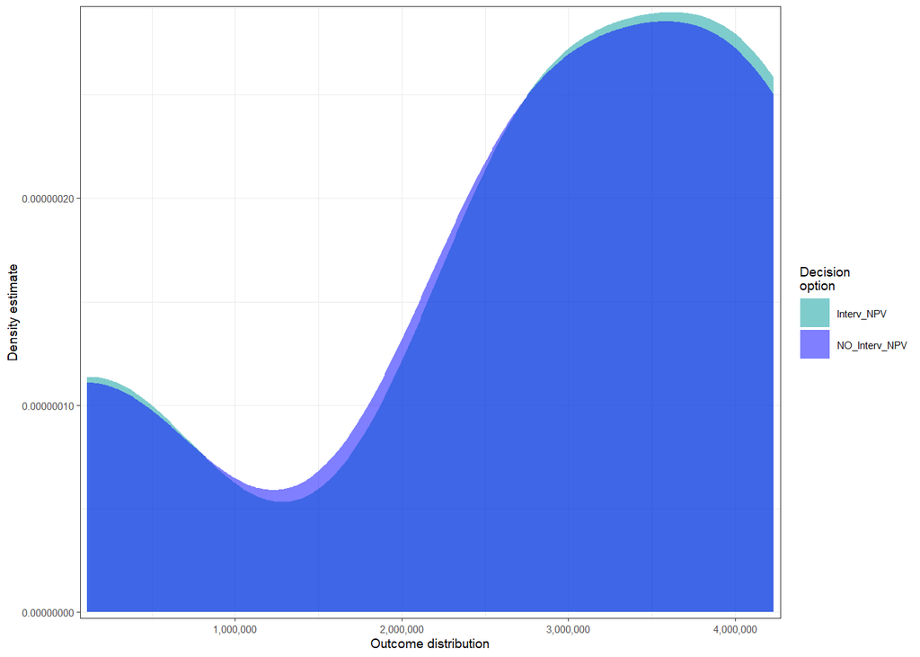

The same can be seen in the boxplot diagram. There are some outliers for both distributions, which are to be expected as well, due to the randomness of the data being drawn resulting in some odd combinations, which would be rarely seen in the real world.

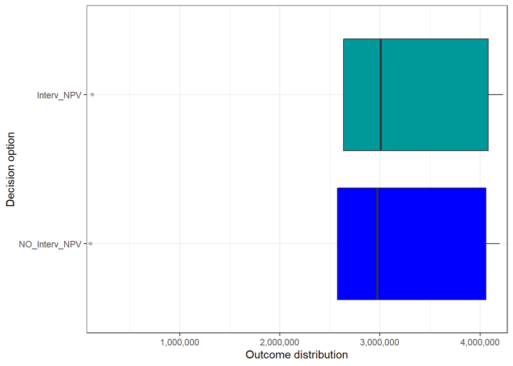

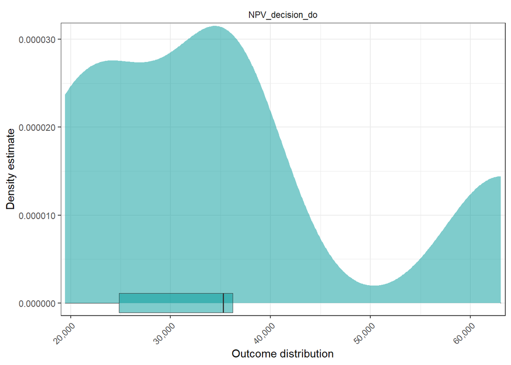

## Cashflow

```r
cashflow <- plot_cashflow(mcSimulation_object = mcSimulation_results,
                          cashflow_var_name = "Cashflow_decision_do")
cashflow <- cashflow + scale_x_continuous(breaks = seq(0,10,2),expand = c(0,0))
```

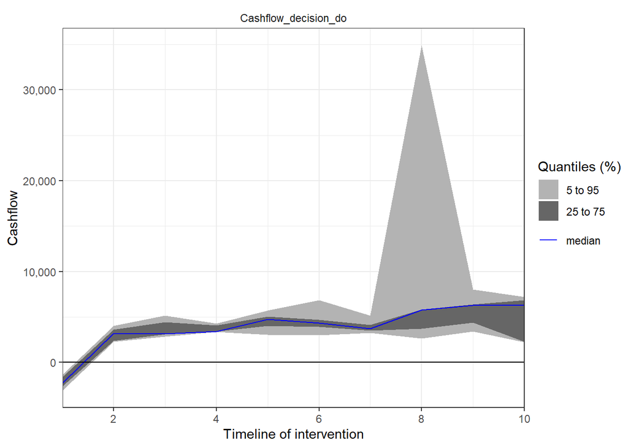

## PLS

```r
## Projection to Latent Structures (PLS) analysis
pls_result <- plsr.mcSimulation(object = mcSimulation_results,
                                resultName = names(mcSimulation_results$y)[3],
                                ncomp = 1)
pls <- plot_pls(pls_result,
                input_table = data.frame(variable = input_table$variable,
                                         label = input_table$label),
                threshold = 0.9)
```

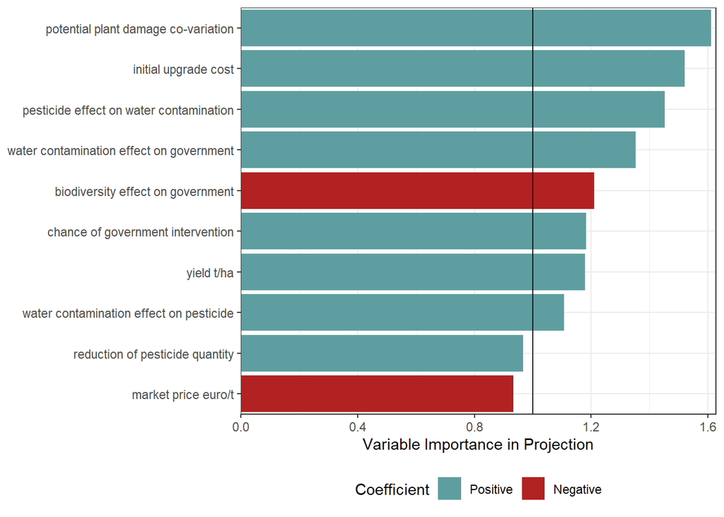

## EVPI

```r
## Value of information (VoI) analysis
evpi_plot <- plot_evpi(evpi, decision_vars = "NPV_decision_do")
```

The EVPI was non-conclusive. There was no merit in finding more precise information to update the boundaries of our model variables.

## Compound figure

```r
compound_fig <- compound_figure(mcSimulation_object = mcSimulation_results,
                                input_table = input_table,
                                plsrResults = pls_result,
                                EVPIresults = evpi,
                                decision_var_name = "NPV_decision_do",
                                cashflow_var_name = "Cashflow_decision_do",
                                base_size = 7)
```

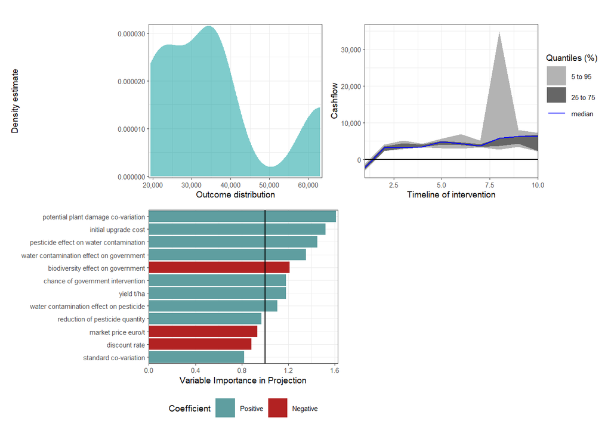

# 9 Discussion

Overall the analysis supports our decision for buying the automated section control sprayer rather then the manual section controlled sprayer. This was expected, as the benefit from the reduced costs of pesticides per year are easily enough to cover the relative small upgrade cost. Surprising though was the big difference between the estimated pesticide cost per year we came up with after our research and the estimates of our experts. This augmented the discrepancy even more. The resulting yearly profit can be seen in the Cashflow, the median effectively shows this sound profit.

As one can also see in the Cashflow is the relative large increase of the fifth to ninety-fifth quantile, which is the government intervention. While the impact on the difference in profit is rather large, it does not occur often enough to seriously shift the distribution. Due to some rather large numbers these cases, the mean still deviates by roughly 10k from the median. The timespan of 10 years is probably not enough, to give a rarely occurring intervention by the government enough impact. Especially due to the delay that was implemented. The delay was still necessary as decisions with such an impact are usually implemented carefully to let the involved parties adapt accordingly. So a implemented intervention by the government should be really rare or impossible within the first two years. The ten year timespan was chosen because it is the legal time to write off an agricultural machine for a farmer. A larger timespan would also benefit the ASCS, so a further investigation for a longer timespan was not carried out.

Another factor regarding the governments intervention is the type of intervention. As it involves politics, this is a complex topic to predict as political focus can shift frequently and is volatile. The results are often complex regulations, which are beyond the scope of this course. Thus we settled for a pesticide limit. It is easy to implement, reduces the pesticides quantity applied effectively and in the long run mostly harms farmers who rely on pesticides too much. With this in mind a limit to the current average pesticide quantity used by orchard farmers was set. In reality such an intervention being implemented within only a few years can still be considered a strong regulation and thereby represents a good compromise for this model.

For our model the `reduction of pesticide quantity` for the ASCS was set to a range of 5 -15 %. This was without reducing the effect of the application. Some of the experts estimated that this reduction would increase if the orchards get more heterogeneous, this tends to be the case in the north eastern regions of Germany. Rough estimates up to 30 %. Most of the experts we asked about this matter are from the KOB or related facilities. In this south western region of Germany the trees in the orchards are rather homogeneous, because of the humid climate and good soil conditions. To increase the authenticity of the estimations for pesticide reduction on a larger scale, experts from other facilities with different growth conditions and orchard structure should be included.

Erdal Ozkan from the agricultural College of the Ohio State University estimated the reduction of pesticide application of a comparable sprayer system he worked with in 2013 to be 47 – 73 %. This estimate is far higher than what the experts questioned for this project estimated. The reasons for that `are likely to be` a comparison to older, not section controlled, sprayers and the different structure and a higher heterogeneity of orchards in the USA compared to Germany. Ozakan is also talking about orchards in general, the tree density in other fruit cultures tends to be lower than in apple orchards, were it ranges from 2500 – 3500 trees*ha^-1 or even higher, depending on the system. This increases the heterogeneity of the plant area, were the pesticides need to be applied. Summarizing all these various findings for possible pesticide reduction would dilute regional characteristics. An adapted recalculation for the specific region the farmers lives in is thus advised.

Other data e.g., the likelihood, that the government is limiting the amount of pesticides allowed to be applied, depending on the biodiversity, is difficult to estimate. For this factor and similar data ranges were set after discussing them and getting some external opinions. To get more reliable data on these factors a large survey, with different experts working in different fields of expertise, would be required.

Even though the chosen 10 year timespan was already discussed, a note should be made that the model is programmed to run for a longer period as well, but there currently are some other mechanism missing to support longer timespans. The biodiversity for example needs a saturation function over time, to not create a self sustaining feedback loop. But this requires a deep understanding of the underlying ecological process and might be to much for farmer to consider. This is also of no concern because of the limited time frame, which prevents such feedback loops with the current parameters.

The model uses relative values for factors that are hard to quantity (e.g., biodiversity). These values are not capped.

`To increase ease of use for practical application some simplifications can be implemented. Removing the parts for biodiversity, water contamination, government concerns and customer behaviour completely would reduce the model to an investment calculator for sprayers working with ranges instead of average values.`

# 10 Conclusion

## 10.2 Recommendation

As the results of the model of this project has shown, there is a clear recommendation to invest in an ASCS. The economic advantage compared to the MSCS is going to vary from case to case, but in any case, there is an advantage.

In addition, the amount of pesticides applied in orchards is going to be decreased. This is going to reduce the stress for the local environment.

# References

Ali E., Abbas, and Howard Ronald A. n.d. *Foundations of Decision Analysis PDF eBook*. Pearson Higher Ed.

“Applying the mcSimulation Function in decisionSupport.” n.d. https://cran.r-project.org/web/packages/decisionSupport/vignettes/example_decision_function.html.

Bundesamt, Statistisches. n.d. “Ökologische Anbauflächen von Obst.” Accessed July 4, 2021. https://www.destatis.de/DE/Themen/Branchen-Unternehmen/Landwirtschaft-Forstwirtschaft-Fischerei/Obst-Gemuese-Gartenbau/Tabellen/oekologisches-obst.html.

Bundesministerium der Finanzen. n.d. “AfA-Tabelle für den Wirtschaftszweig "Landwirtschaft und Tierzucht" - Bundesfinanzministerium - Themen.” https://www.bundesfinanzministerium.de/Content/DE/Standardartikel/Themen/Steuern/Weitere_Steuerthemen/Betriebspruefung/AfA-Tabellen/AfA-Tabelle_Landwirtschaft-und-Tierzucht.html.

Byron K., Williams, and Johnson Fred A. n.d. “Value of information in natural resource management: technical developments and application to pink-footed geese.” *Ecology and Evolution* 5: 466–74. https://doi.org/10.1002/ece3.1363.

Cory, Whitney, and Luedeling Eike. n.d. “Decision Analysis and Forecasting for Agricultural Development.” Accessed August 10, 2021. http://htmlpreview.github.io/?https://github.com/CWWhitney/Decision_Analysis_Course/blob/main/Index.html.

Denis, Lanzanova, Whitney Cory, Shepherd Keith, and Luedeling Eike. n.d. “Improving development efficiency through decision analysis: Reservoir protection in Burkina Faso.” *Environmental Modelling & Software* 115: 164–75. https://doi.org/10.1016/j.envsoft.2019.01.016.

Douglas W., Hubbard. 2014. *How to Measure Anything: Finding the Value of Intangibles in Business*. John Wiley & Sons.

Eike, Luedeling, and Shepherd Keith. n.d. “Decision-Focused Agricultural Research.” *Solutions* 7: 46–54.

Eike, Luedeling, Goehring Lutz, Schiffers Katja, Whittney Cory, and Fernandez Eduardo. n.d. “decisionSupport: quantitative support of decision making under uncertainty.” *Contributed Package to the R Programming Language. Version 1.103* 2.

Hoa, Do, Luedeling Eike, and Whitney Cory. n.d. “Decision analysis of agroforestry options reveals adoption risks for resource-poor farmers.” *Agronomy for Sustainable Development* 40: 1–12.

Karl, Claxton, Griffin Susan, Koffijberg Hendrik, and McKenna Claire. n.d. “How to estimate the health benefits of additional research and changing clinical practice.” *Bmj* 351.

Keith, Shepherd, Hubbard Douglas, Fenton Norman, Claxton Karl, Luedeling Eike, and de Leeuw Jan. n.d. “Policy: Development goals should enable decision-making.” *Nature News* 523: 152.

Michael, Carley. n.d. *Rational techniques in policy analysis: Policy studies institute*. Elsevier.

Sibylle, Wilke. 2013. “Pflanzenschutzmittelverwendung in der Landwirtschaft.” https://www.umweltbundesamt.de/daten/land-forstwirtschaft/pflanzenschutzmittelverwendung-in-der.

Tobias, Frische, Egerer Sina, Matezki Steffen, and Wogram Christina Pickl Jörn. n.d. “5-Punkte-Programm für einen nachhaltigen Pflanzenschutz,” 36.